# CM1 SIM

M0725077_Zahra Binta Azhari

2026-05-26

# Analisis Database Sakila

Sistem Informasi Manajemen | Case Method 1

## Korelasi antara Durasi Sewa dan Jumlah Pembayaran

### Deskripsi

Tujuan dari analisis ini adalah untuk membuktikan secara statistik apakah durasi pinjam film, dihitung dalam satuan hari, memiliki korelasi linear dengan jumlah biaya yang dibayar pelanggan. Memahami seberapa efektif skema penarifan pada sistem manajemen Sakila bergantung pada informasi ini.

### Hipotesis

- Hipotesis Nol ($H_0$): Tidak ada korelasi linear antara durasi peminjaman dan biaya yang dibayar ($\rho = 0$).
- Hipotesis Alternatif ($H_1$): Terdapat korelasi linear antara durasi peminjaman dan biaya yang dibayar ($\rho \neq 0$).

Koefisien korelasi Pearson ($r$) dihitung menggunakan rumus matematika berikut:
$$r = \frac{\sum_{i=1}^{n} (X_i - \bar{X})(Y_i -
\bar{Y})}{\sqrt{\sum_{i=1}^{n} (X_i - \bar{X})^2 \sum_{i=1}^{n} (Y_i -
\bar{Y})^2}}$$
Keterangan: $X$ merupakan durasi peminjaman (hari) dan $Y$ merupakan biaya bayar (USD).

### Pengambilan Data & Analisis Data

```r
# Ambil data menggunakan DATEDIFF
df_korelasi <- dbGetQuery(con, "
  SELECT
    DATEDIFF(r.return_date, r.rental_date) AS durasi_hari,
    p.amount AS biaya_bayar
  FROM rental r
  JOIN payment p ON r.rental_id = p.rental_id
  WHERE r.return_date IS NOT NULL
")

# Jalankan Uji Korelasi Pearson
uji_korelasi <- cor.test(df_korelasi$durasi_hari, df_korelasi$biaya_bayar, method = "pearson")
uji_korelasi
```

```
##
##  Pearson's product-moment correlation
##
## data:  df_korelasi$durasi_hari and df_korelasi$biaya_bayar
## t = 59.735, df = 15859, p-value < 2.2e-16
## alternative hypothesis: true correlation is not equal to 0
## 95 percent confidence interval:
##  0.4157818 0.4411916
## sample estimates:
##       cor
## 0.4285714
```

### Visualisasi

```
## Defaulting to continuous.
```

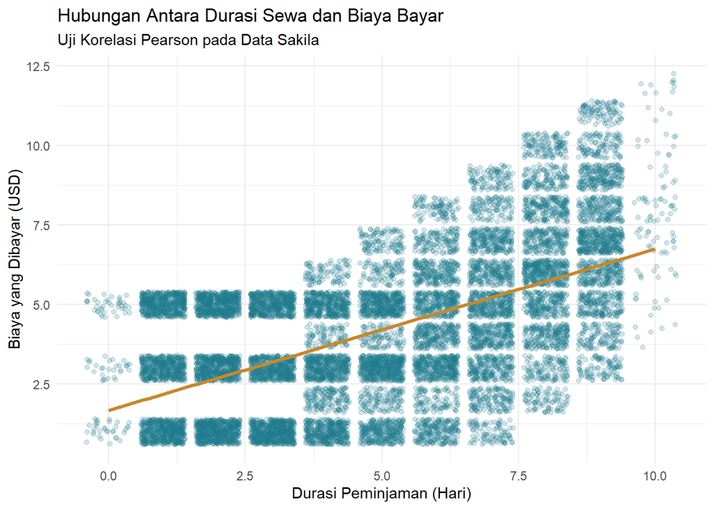

```r
ggplot(df_korelasi, aes(x = durasi_hari, y = biaya_bayar)) +
  geom_jitter(color = "#1D7A8C", alpha = 0.2) + # Jitter digunakan agar titik tidak menumpuk
  geom_smooth(method = "lm", color = "#C8882A", se = FALSE, size = 1.2) +
  labs(
    title = "Hubungan Antara Durasi Sewa dan Biaya Bayar",
    subtitle = "Uji Korelasi Pearson pada Data Sakila",
    x = "Durasi Peminjaman (Hari)",
    y = "Biaya yang Dibayar (USD)"
  ) +
  theme_minimal()
```

### Interpretasi

**Kesimpulan:** Hasil uji korelasi Pearson menunjukkan bahwa ada nilai p-value yang sangat kecil (< 0.05), yang menunjukkan bahwa hubungan tersebut signifikan secara statistik, sehingga kami menolak $H_0$.

## Perbedaan Rata-rata Transaksi antar Toko

### Deskripsi

Toko Sakila terletak di dua lokasi perbelanjaan yang berbeda ada Toko 1 dan Toko 2. Dalam analisis ini, uji statistik inferensial Independent T-Test digunakan untuk menentukan apakah performa finansial, atau rata-rata nilai transaksi per kasir, di kedua toko tersebut memiliki perbedaan yang signifikan atau identik.

### Hipotesis

- Hipotesis Nol ($H_0$): Rata-rata nominal transaksi di Store 1 sama dengan Store 2 ($\mu_1 = \mu_2$).
- Hipotesis Alternatif ($H_1$): Rata-rata nominal transaksi di Store 1 tidak sama dengan Store 2 ($\mu_1 \neq \mu_2$).

Uji statistik menggunakan rumus Welch’s T-Test (asumsi varians tidak seragam):
$$t = \frac{\bar{X}_1 -
\bar{X}_2}{\sqrt{\frac{s_1^2}{n_1} + \frac{s_2^2}{n_2}}}$$

### Pengambilan Data & Analisis Data

```r
# Ambil data ID Toko dan nominal pembayaran pelanggan
df_ttest <- dbGetQuery(con, "
  SELECT c.store_id, p.amount AS biaya_bayar
  FROM payment p
  JOIN customer c ON p.customer_id = c.customer_id
")

# Konversi store_id menjadi bentuk faktor/kategori
df_ttest$store_id <- as.factor(df_ttest$store_id)

# Jalankan Uji T-Test Independen
uji_t <- t.test(biaya_bayar ~ store_id, data = df_ttest)
uji_t
```

```
##
##  Welch Two Sample t-test
##
## data:  biaya_bayar by store_id
## t = 1.6675, df = 15587, p-value = 0.09544
## alternative hypothesis: true difference in means between group 1 and group 2 is not equal to 0
## 95 percent confidence interval:
##  -0.01095276  0.13576514
## sample estimates:
## mean in group 1 mean in group 2
##        4.229739        4.167333
```

### Visualisasi

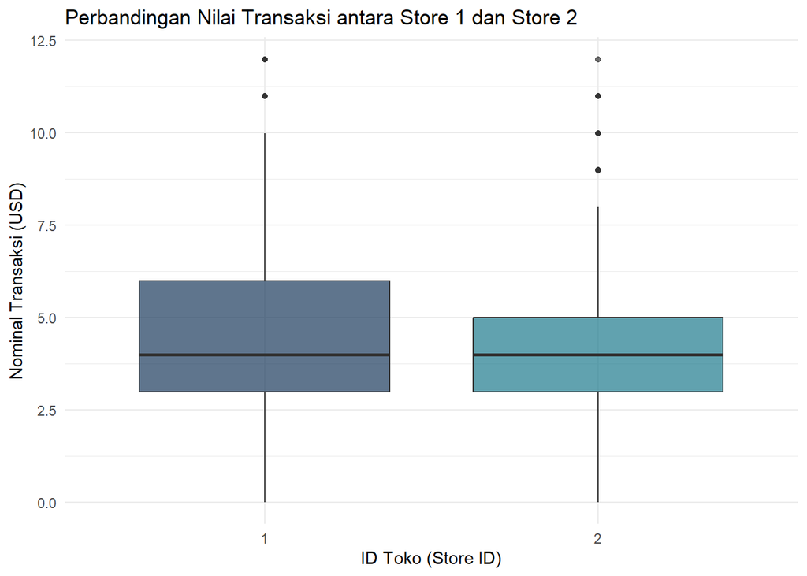

```r
ggplot(df_ttest, aes(x = store_id, y = biaya_bayar, fill = store_id)) +
  geom_boxplot(alpha = 0.7, show.legend = FALSE) +
  scale_fill_manual(values = c("1" = "#1A3A5C", "2" = "#1D7A8C")) +
  labs(
    title = "Perbandingan Nilai Transaksi antara Store 1 dan Store 2",
    x = "ID Toko (Store ID)",
    y = "Nominal Transaksi (USD)"
  ) +
  theme_minimal()
```

### Interpretasi

**Kesimpulan:** Hasilnya menunjukkan bahwa nilai p-value yang keluar pada konsol output harus diperhatikan: jika nilai **p-value > 0.05**, maka kita **gagal menolak** $H_0$.